# PML_CP

Mindy Ng

November 21, 2015

OSX El Capitan Version 10.11.1 and RSudio Version 0.99.484 were used to complete this prediction write-up.

(‘Background’, ‘Data’ and ‘What you should submit’ sections are directly copied from course’s assignment page)

Background:

Using devices such as Jawbone Up, Nike FuelBand, and Fitbit it is now possible to collect a large amount of data about personal activity relatively inexpensively. These type of devices are part of the quantified self movement - a group of enthusiasts who take measurements about themselves regularly to improve their health, to find patterns in their behavior, or because they are tech geeks. One thing that people regularly do is quantify how much of a particular activity they do, but they rarely quantify how well they do it. In this project, your goal will be to use data from accelerometers on the belt, forearm, arm, and dumbell of 6 participants. They were asked to perform barbell lifts correctly and incorrectly in 5 different ways. More information is available from the website here: http://groupware.les.inf.puc-rio.br/har (see the section on the Weight Lifting Exercise Dataset).

Data:

The training data for this project are available here: [https://d396qusza40orc.cloudfront.net/predmachlearn/pml-training.csv]

The test data are available here: [https://d396qusza40orc.cloudfront.net/predmachlearn/pml-testing.csv]

The data for this project come from this source: [http://groupware.les.inf.puc-rio.br/har]. If you use the document you create for this class for any purpose please cite them as they have been very generous in allowing their data to be used for this kind of assignment.

What you should submit:

The goal of your project is to predict the manner in which they did the exercise. This is the “classe” variable in the training set. You may use any of the other variables to predict with. You should create a report describing how you built your model, how you used cross validation, what you think the expected out of sample error is, and why you made the choices you did. You will also use your prediction model to predict 20 different test cases.

Your submission should consist of a link to a Github repo with your R markdown and compiled HTML file describing your analysis. Please constrain the text of the writeup to < 2000 words and the number of figures to be less than 5. It will make it easier for the graders if you submit a repo with a gh-pages branch so the HTML page can be viewed online (and you always want to make it easy on graders :-). You should also apply your machine learning algorithm to the 20 test cases available in the test data above. Please submit your predictions in appropriate format to the programming assignment for automated grading. See the programming assignment for additional details.

Preliminary Work

Reproducibility

A pseudo-random number generator seed was set at 1122 for all code. In order to reproduce the results below, the same seed should be used.

Required packages for reproducibility were downloaded and installed, such as caret and randomForest.

HOW MODEL WAS BUILT.

Our outcome variable is classe, a factor variable with 5 levels. For this data set, “participants were asked to perform one set of 10 repetitions of the Unilateral Dumbbell Biceps Curl in 5 different fashions:

- exactly according to the specification (Class A)
- throwing the elbows to the front (Class B)
- lifting the dumbbell only halfway (Class C)
- lowering the dumbbell only halfway (Class D)
- throwing the hips to the front (Class E)

Class A corresponds to the specified execution of the exercise, while the other 4 classes correspond to common mistakes." [1] Determining how good a prediction evaluation is will be based on how much it maximizes the accuracy and minimizes the out-of-sample error. All other available variables will be used for prediction. Two prediction models that will be assessed are decision tree and random forest algorithms. The model with the highest accuracy will be chosen as our final model.

CROSS-VALIDATION.

Cross-validation will be performed by subsampling our training data set randomly without replacement into 2 subsamples: subTraining data (75% of the original Training data set) and subTesting data (25% of the original Training data set). Our models will be fitted on the subTraining data set, and tested on the subTesting data set. Once the most accurate model is chosen, it will be tested on the original Testing data set.

EXPECTED OUT-OF-SAMPLE ERROR.

The expected out-of-sample error will correspond to the quantity: 1-Accuracy in the cross-validation data. Accuracy is the proportion of correctly classified observation over the total sample in the subTesting data set. Expected accuracy is the expected accuracy in the out-of-sample data set (i.e. original testing data set). Thus, the expected value of the out-of-sample error will correspond to the expected number of missclassified observations/total observations in the Test data set, which is the quantity: 1-Accuracy found from the cross-validation data set.

WHY I MADE THE CHOICES I DID.

Our outcome variable “classe” is an unordered factor variable. Thus, we can choose our error type as 1-Accuracy. We have a large sample size with N= 19622 in the Training data set. This allows us to divide our Training sample into subTraining and subTesting sets for there to be cross-validation. Features with all missing values will be discarded as well as features that are irrelevant. All other features will be kept as relevant variables. Decision tree and random forest algorithms are known for their ability of detecting the features that are important for classification [2]. Feature selection is inherent, so it is not so necessary at the data preparation phase. Thus, there won’t be a feature selection section in this report.

Code and Results:

Packages, Libraries, Seed

Installing packages, loading libraries, and setting the seed for reproducibility:

```r
#install.packages("caret")
#install.packages("randomForest")
#install.packages("rpart")

library(caret)
```

```r
## Loading required package: lattice
## Loading required package: ggplot2
library(randomForest) #Random forest for classification and regression
## randomForest 4.6-12
library(rpart) # Regressive Partitioning and Regression trees
library(rpart.plot) # Decision Tree plot

# setting the overall seed for reproducibility
set.seed(1122)
```

Loading data sets and preliminary cleaning on them.

First, we want to load the data sets into R. Then, we want to make sure that missing values are coded correctly. Last, irrelevant variables will be deleted.

```r
# Save both data sets into my working directory,
# Some missing values are originally coded as string "#DIV/0!" or "" or "NA". These will be changed to NA.
# We notice that both data sets contain columns with all missing values. These will be deleted.

# Loading the training data.
training <- read.csv('pml-training.csv', na.strings=c("NA","#DIV/0!", ""))

# Loading the testing data set.
testing <- read.csv('pml-testing.csv', na.strings=c("NA","#DIV/0!", ""))

# Check dimensions for number of variables and number of observations.
dim(training)
```

```
## [1] 19622   160
```

```r
dim(testing)
```

```
## [1]  20 160
```

```r
# Delete columns with all missing values.
training<-training[,colSums(is.na(training)) == 0]
testing <-testing[,colSums(is.na(testing)) == 0]

# Some variables are irrelevant for our needs, such as: user_name, raw_timestamp_part_1, raw_timestamp_part_,2 cvtd_timestamp, new_window, and  num_window (columns 1 to 7). We can delete these variables.
training <-training[,-c(1:7)]
testing <-testing[,-c(1:7)]

# Take a look at newly processed datasets:
dim(training)
```

```
## [1] 19622    53
```

```r
dim(testing)
```

```
## [1] 20 53
```

```r
head(training)
```

```
##   roll_belt pitch_belt yaw_belt total_accel_belt gyros_belt_x gyros_belt_y
## 1      1.41       8.07    -94.4                3         0.00         0.00
## 2      1.41       8.07    -94.4                3         0.02         0.00
## 3      1.42       8.07    -94.4                3         0.00         0.00
## 4      1.48       8.05    -94.4                3         0.02         0.00
## 5      1.48       8.07    -94.4                3         0.02         0.02
## 6      1.45       8.06    -94.4                3         0.02         0.00
##   gyros_belt_z accel_belt_x accel_belt_y accel_belt_z magnet_belt_x
## 1        -0.02          -21            4           22            -3
## 2        -0.02          -22            4           22            -7
## 3        -0.02          -20            5           23            -2
## 4        -0.03          -22            3           21            -6
## 5        -0.02          -21            2           24            -6
## 6        -0.02          -21            4           21             0
##   magnet_belt_y magnet_belt_z roll_arm pitch_arm yaw_arm total_accel_arm
```

[output cut: 69 more lines]

```r
head(testing)
```

```
##   roll_belt pitch_belt yaw_belt total_accel_belt gyros_belt_x gyros_belt_y
## 1    123.00      27.00    -4.75               20        -0.50        -0.02
## 2      1.02       4.87   -88.90                4        -0.06        -0.02
## 3      0.87       1.82   -88.50                5         0.05         0.02
## 4    125.00     -41.60   162.00               17         0.11         0.11
## 5      1.35       3.33   -88.60                3         0.03         0.02
## 6     -5.92       1.59   -87.70                4         0.10         0.05
##   gyros_belt_z accel_belt_x accel_belt_y accel_belt_z magnet_belt_x
## 1        -0.46          -38           69         -179           -13
## 2        -0.07          -13           11           39            43
## 3         0.03            1           -1           49            29
## 4        -0.16           46           45         -156           169
## 5         0.00           -8            4           27            33
## 6        -0.13          -11          -16           38            31
##   magnet_belt_y magnet_belt_z roll_arm pitch_arm yaw_arm total_accel_arm
```

[output cut: 69 more lines]

Partitioning the training data set to allow cross-validation.

The training data set contains 53 variables and 19622 obs. The testing data set contains 53 variables and 20 obs. In order to perform cross-validation, the training data set is partionned into 2 sets: subTraining (75%) and subTesting (25%). This will be performed using random subsampling without replacement.

```r
subsamples <- createDataPartition(y=training$classe, p=0.75, list=FALSE)
subTraining <- training[subsamples, ]
subTesting <- training[-subsamples, ]
dim(subTraining)
```

```
## [1] 14718    53
```

```r
dim(subTesting)
```

```
## [1] 4904   53
```

```r
head(subTraining)
```

```
##   roll_belt pitch_belt yaw_belt total_accel_belt gyros_belt_x gyros_belt_y
## 1      1.41       8.07    -94.4                3         0.00         0.00
## 2      1.41       8.07    -94.4                3         0.02         0.00
## 4      1.48       8.05    -94.4                3         0.02         0.00
## 5      1.48       8.07    -94.4                3         0.02         0.02
## 6      1.45       8.06    -94.4                3         0.02         0.00
## 7      1.42       8.09    -94.4                3         0.02         0.00
##   gyros_belt_z accel_belt_x accel_belt_y accel_belt_z magnet_belt_x
## 1        -0.02          -21            4           22            -3
## 2        -0.02          -22            4           22            -7
## 4        -0.03          -22            3           21            -6
## 5        -0.02          -21            2           24            -6
## 6        -0.02          -21            4           21             0
## 7        -0.02          -22            3           21            -4
##   magnet_belt_y magnet_belt_z roll_arm pitch_arm yaw_arm total_accel_arm
```

[output cut: 69 more lines]

```r
head(subTesting)
```

```
##    roll_belt pitch_belt yaw_belt total_accel_belt gyros_belt_x
## 3       1.42       8.07    -94.4                3         0.00
## 23      1.56       8.10    -94.3                3         0.02
## 29      1.52       8.16    -94.4                3         0.03
## 37      1.41       8.11    -94.3                3         0.00
## 56      1.27       7.46    -94.1                3         0.03
## 57      1.25       7.45    -94.1                3         0.02
##    gyros_belt_y gyros_belt_z accel_belt_x accel_belt_y accel_belt_z
## 3          0.00        -0.02          -20            5           23
## 23         0.00        -0.02          -21            4           21
## 29         0.00        -0.02          -20            4           23
## 37         0.02        -0.02          -20            3           22
## 56         0.00        -0.02          -18            3           20
## 57         0.00        -0.02          -19            1           23
##    magnet_belt_x magnet_belt_y magnet_belt_z roll_arm pitch_arm yaw_arm
```

[output cut: 69 more lines]

A look at the Data.

The variable “classe” contains 5 levels: A, B, C, D and E. A plot of the variable’s outcome will allow us to see the frequency of each level. This can be used to compare each level to one another.

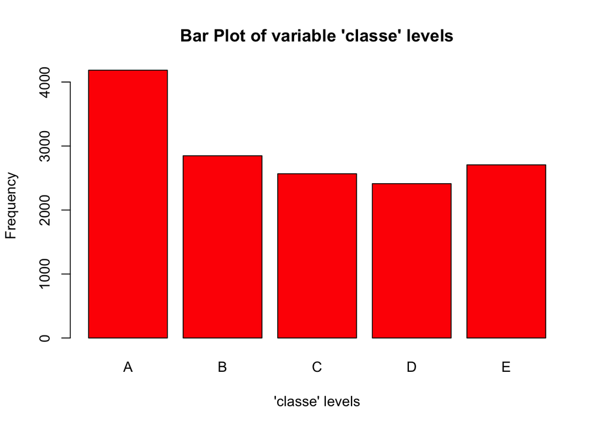

```r
plot(subTraining$classe, col="red", main="Bar Plot of variable 'classe' levels", xlab="'classe' levels", ylab="Frequency")
```

From the graph above, we can see that on the most part, each level’s frequency is within the same order of magnitude of each other. Though, Level A is the most frequent with more than 4000 occurrences while level D is the least frequent with about 2500 occurrences.

First prediction model: Decision Tree

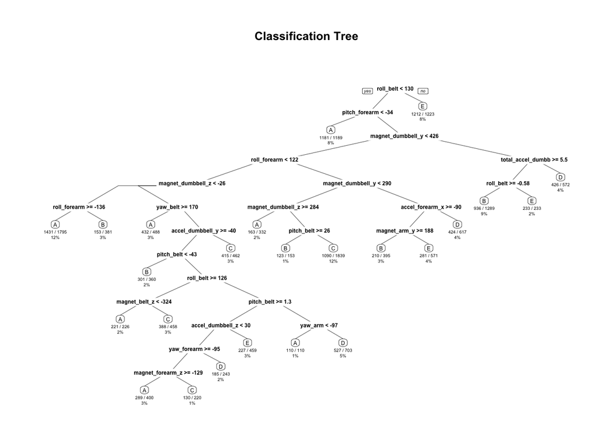

```r
FirstModel <- rpart(classe ~ ., data=subTraining, method="class")

# Predicting:
FirstPrediction <- predict(FirstModel, subTesting, type = "class")

# Plot of the Decision Tree:
rpart.plot(FirstModel, main="Classification Tree", extra=102, under=TRUE, faclen=0)
```

```r
# Test results on our subTesting data set:
confusionMatrix(FirstPrediction, subTesting$classe)
```

```
## Confusion Matrix and Statistics
##
##           Reference
## Prediction    A    B    C    D    E
##          A 1274  146   17   49   35
##          B   53  559   69   68   79
##          C   31   79  696  119   74
##          D   14   73   48  508   53
##          E   23   92   25   60  660
##
## Overall Statistics
##
##                Accuracy : 0.7539
##                  95% CI : (0.7416, 0.7659)
##     No Information Rate : 0.2845
##     P-Value [Acc > NIR] : < 2.2e-16
##
##                   Kappa : 0.6877
##  Mcnemar's Test P-Value : < 2.2e-16
##
## Statistics by Class:
##
##                      Class: A Class: B Class: C Class: D Class: E
## Sensitivity            0.9133   0.5890   0.8140   0.6318   0.7325
## Specificity            0.9296   0.9320   0.9252   0.9541   0.9500
## Pos Pred Value         0.8376   0.6751   0.6967   0.7299   0.7674
## Neg Pred Value         0.9642   0.9043   0.9593   0.9297   0.9404
## Prevalence             0.2845   0.1935   0.1743   0.1639   0.1837
## Detection Rate         0.2598   0.1140   0.1419   0.1036   0.1346
## Detection Prevalence   0.3102   0.1688   0.2037   0.1419   0.1754
## Balanced Accuracy      0.9214   0.7605   0.8696   0.7930   0.8413
```

Second prediction model: Random Forest

```r
SecondModel <- randomForest(classe ~. , data=subTraining, method="class")

# Predicting:
SecondPrediction <- predict(SecondModel, subTesting, type = "class")

# Test results on subTesting data set:
confusionMatrix(SecondPrediction, subTesting$classe)
```

```
## Confusion Matrix and Statistics
##
##           Reference
## Prediction    A    B    C    D    E
##          A 1391    2    0    0    0
##          B    3  945    4    0    0
##          C    0    2  850    6    0
##          D    0    0    1  798    2
##          E    1    0    0    0  899
##
## Overall Statistics
##
##                Accuracy : 0.9957
##                  95% CI : (0.9935, 0.9973)
##     No Information Rate : 0.2845
##     P-Value [Acc > NIR] : < 2.2e-16
##
##                   Kappa : 0.9946
##  Mcnemar's Test P-Value : NA
##
## Statistics by Class:
##
##                      Class: A Class: B Class: C Class: D Class: E
## Sensitivity            0.9971   0.9958   0.9942   0.9925   0.9978
## Specificity            0.9994   0.9982   0.9980   0.9993   0.9998
## Pos Pred Value         0.9986   0.9926   0.9907   0.9963   0.9989
## Neg Pred Value         0.9989   0.9990   0.9988   0.9985   0.9995
## Prevalence             0.2845   0.1935   0.1743   0.1639   0.1837
## Detection Rate         0.2836   0.1927   0.1733   0.1627   0.1833
## Detection Prevalence   0.2841   0.1941   0.1750   0.1633   0.1835
## Balanced Accuracy      0.9983   0.9970   0.9961   0.9959   0.9988
```

Submission.

```r
# Predict outcome levels on the original Testing data set using Random Forest algorithm.
FinalPrediction <- predict(SecondModel, testing, type="class")
FinalPrediction
```

```
##  1  2  3  4  5  6  7  8  9 10 11 12 13 14 15 16 17 18 19 20
##  B  A  B  A  A  E  D  B  A  A  B  C  B  A  E  E  A  B  B  B
## Levels: A B C D E
```

```r
# Write files for submission
pml_write_files = function(x){
  n = length(x)
  for(i in 1:n){
    filename = paste0("problem_id_",i,".txt")
    write.table(x[i],file=filename,quote=FALSE,row.names=FALSE,col.names=FALSE)
  }
}

pml_write_files(FinalPrediction)
```

References:

[1] Velloso, E.; Bulling, A.; Gellersen, H.; Ugulino, W.; Fuks, H. Qualitative Activity Recognition of Weight Lifting Exercises. Proceedings of 4th International Conference in Cooperation with SIGCHI (Augmented Human ’13) . Stuttgart, Germany: ACM SIGCHI, 2013.

[2] Krzysztof Gra??bczewski and Norbert Jankowski. Feature Selection with Decision Tree Criterion.